# Weather and Corn Yield Regressions

Elin Binck

3/6/2022

## Weather Data Analysis

### Load the PRISM daily maximum temperatures

```r
# daily max temperature
# dimensions: counties x days x years
prism <- readMat("data/prismiowa.mat")

# look at county #1
t_1981_c1 <- prism$tmaxdaily.iowa[1,,1]
t_1981_c1[366]
```

```
## [1] NaN
```

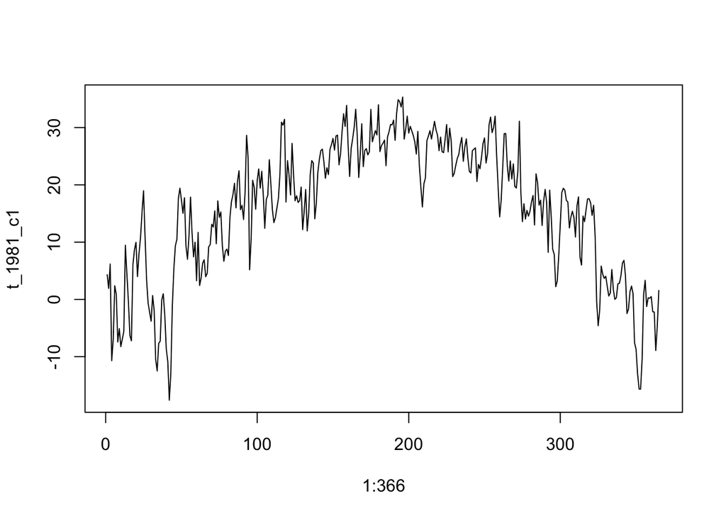

```r
plot(1:366, t_1981_c1, type = "l")
```

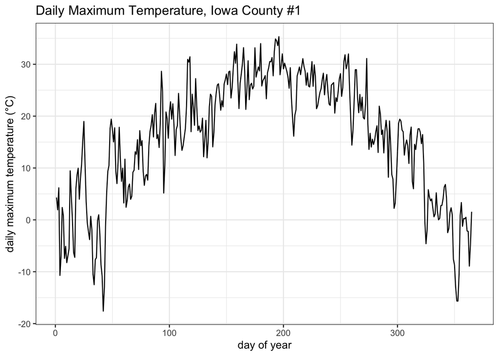

```r
ggplot() +
  geom_line(mapping = aes(x=1:366, y = t_1981_c1)) +
  theme_bw() +
  xlab("day of year") +
  ylab("daily maximum temperature (°C)") +
  ggtitle("Daily Maximum Temperature, Iowa County #1")
```

# Tidy the data

```r
# assign dimension names to tmax matrix
dimnames(prism$tmaxdaily.iowa) <- list(prism$COUNTYFP, 1:366, prism$years)

# convert 3d matrix into a data frame
tmaxdf <- as.data.frame.table(prism$tmaxdaily.iowa)

# relabel the columns
colnames(tmaxdf) <- c("countyfp","doy","year","tmax")
tmaxdf <- tibble(tmaxdf)
```

## Temperature trends

### Summer temperature trends: Winneshiek County

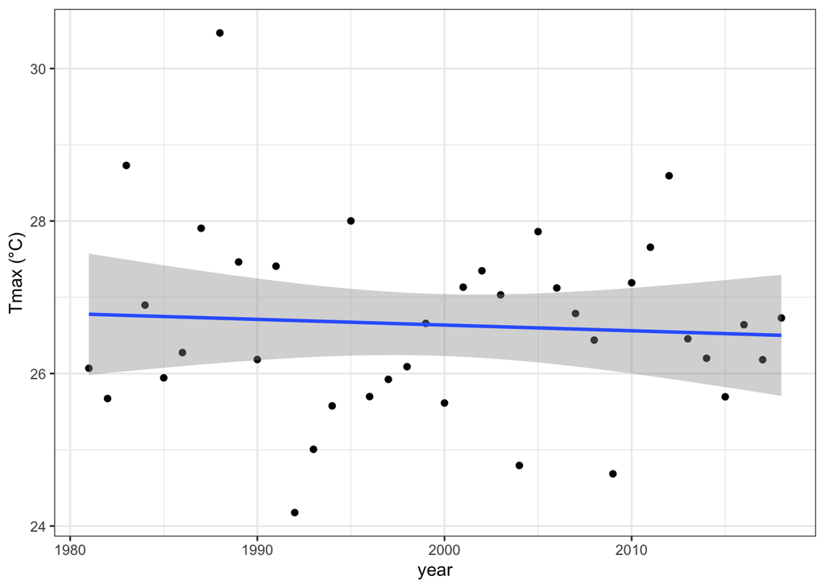

```r
tmaxdf$doy <- as.numeric(tmaxdf$doy)
tmaxdf$year <- as.numeric(as.character(tmaxdf$year))

winnesummer <- tmaxdf %>%
  filter(countyfp==191 & doy >= 152 & doy <= 243) %>%
  group_by(year) %>%
  summarize(meantmax = mean(tmax))

ggplot(winnesummer, mapping = aes(x = year, y = meantmax)) +
  geom_point() +
  theme_bw() +
  labs(x = "year", y = "Tmax (°C)") +
  geom_smooth(method = lm)
```

```r
lm_summertmax <- lm(meantmax ~ year, winnesummer)
summary(lm_summertmax)
```

```
##
## Call:
## lm(formula = meantmax ~ year, data = winnesummer)
##
## Residuals:
##     Min      1Q  Median      3Q     Max
## -2.5189 -0.7867 -0.0341  0.6859  3.7415
##
## Coefficients:
##             Estimate Std. Error t value Pr(>|t|)
## (Intercept) 41.57670   36.44848   1.141    0.262
## year        -0.00747    0.01823  -0.410    0.684
##
## Residual standard error: 1.232 on 36 degrees of freedom
## Multiple R-squared:  0.004644,   Adjusted R-squared:  -0.02301
## F-statistic: 0.168 on 1 and 36 DF,  p-value: 0.6844
```

### Winter Temperatures - Winneshiek County

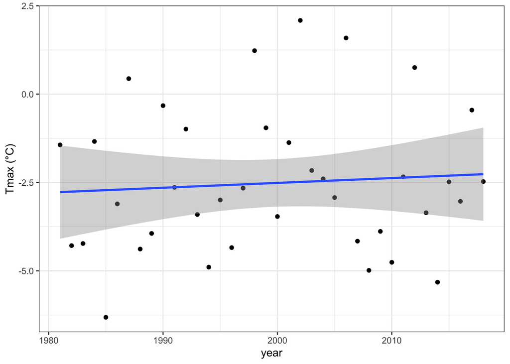

```r
winnewinter <- tmaxdf %>%
  filter(countyfp==191 & (doy <= 59 | doy >= 335) & !is.na(tmax)) %>%
  group_by(year) %>%
  summarize(meantmax = mean(tmax))

ggplot(winnewinter, mapping = aes(x = year, y = meantmax)) +
  geom_point() +
  theme_bw() +
  labs(x = "year", y = "Tmax (°C)") +
  geom_smooth(method = lm)
```

```r
lm_wintertmax <- lm(meantmax ~ year, winnewinter)
summary(lm_wintertmax)
```

```
##
## Call:
## lm(formula = meantmax ~ year, data = winnewinter)
##
## Residuals:
##     Min      1Q  Median      3Q     Max
## -3.5978 -1.4917 -0.3053  1.3778  4.5709
##
## Coefficients:
##              Estimate Std. Error t value Pr(>|t|)
## (Intercept) -29.87825   60.48100  -0.494    0.624
## year          0.01368    0.03025   0.452    0.654
##
## Residual standard error: 2.045 on 36 degrees of freedom
## Multiple R-squared:  0.005652,   Adjusted R-squared:  -0.02197
## F-statistic: 0.2046 on 1 and 36 DF,  p-value: 0.6537
```

### Multiple regression – Quadratic time trend

```r
winnewinter$yearsq <- winnewinter$year^2

lm_wintertmaxquad <- lm(meantmax ~ year + yearsq, winnewinter)
summary(lm_wintertmaxquad)
```

```
##
## Call:
## lm(formula = meantmax ~ year + yearsq, data = winnewinter)
##
## Residuals:
##     Min      1Q  Median      3Q     Max
## -3.3539 -1.2985 -0.2813  1.4055  4.2620
##
## Coefficients:
##               Estimate Std. Error t value Pr(>|t|)
## (Intercept) -1.086e+04  1.238e+04  -0.877    0.386
## year         1.085e+01  1.239e+01   0.876    0.387
## yearsq      -2.710e-03  3.097e-03  -0.875    0.388
##
## Residual standard error: 2.051 on 35 degrees of freedom
## Multiple R-squared:  0.02694,    Adjusted R-squared:  -0.02867
## F-statistic: 0.4845 on 2 and 35 DF,  p-value: 0.6201
```

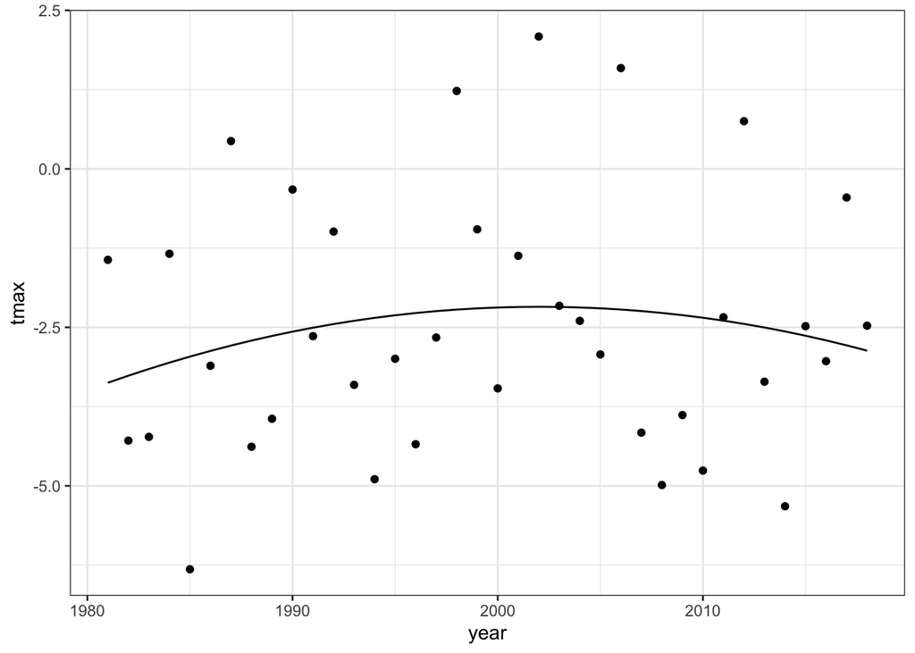

```r
winnewinter$fitted <- lm_wintertmaxquad$fitted.values

ggplot(winnewinter) +
  geom_point(mapping = aes(x = year, y = meantmax)) +
  geom_line(mapping = aes(x = year, y = fitted)) +
  theme_bw() +
  labs(x = "year", y = "tmax")
```

### Download NASS corn yield data

```r
# set our API key with NASS
nassqs_auth(key = "F470D9A0-22C7-39FB-95F1-5535C03C02B9")

# parameters to query on
params <- list(commodity_desc = "CORN", util_practice_desc = "GRAIN", prodn_practice_desc = "ALL PRODUCTION PRACTICES", year__GE = 1981, state_alpha = "IA")

# download
cornyieldsall <- nassqs_yields(params)
cornyieldsall$county_ansi <- as.numeric(cornyieldsall$county_ansi)
cornyieldsall$yield <- as.numeric(cornyieldsall$Value)

# clean and filter this dataset
cornyields <- select(cornyieldsall, county_ansi, county_name, yield, year) %>%
  filter(!is.na(county_ansi) & !is.na(yield))
cornyields <- tibble(cornyields)
```

## Assignment

### Question 1a: Extract Winneshiek County corn yields, fit a linear time trend, make a plot. Is there a significant time trend?

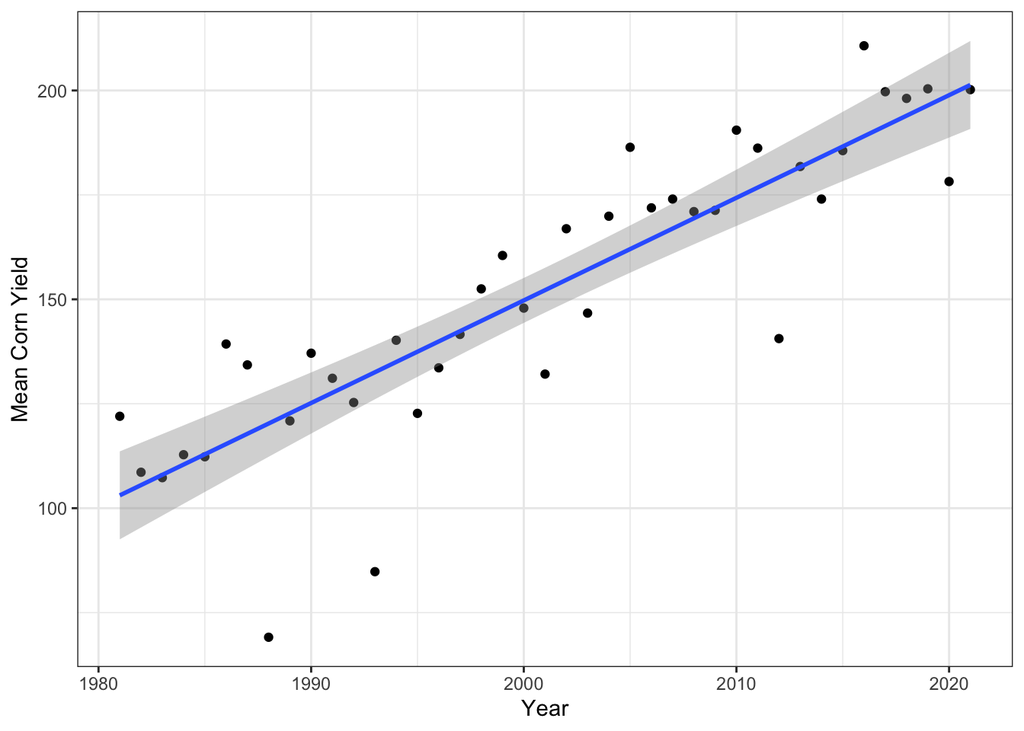

```r
winneyields <- cornyields %>%
  filter(county_ansi==191) %>%
  group_by(year) %>%
  summarize(meanyield = mean(yield))

ggplot(data = winneyields, aes(x = year, y = meanyield))+
  geom_point()+
  theme_bw()+
  labs(x = "Year", y = "Mean Corn Yield")+
  geom_smooth(method = lm)
```

### Question 1b: Fit a quadratic time trend (i.e., year + year^2) and make a plot. Is there evidence for slowing yield growth?

```r
winneyields$yearsq <- winneyields$year^2

lm_yieldsquad <- lm(meanyield ~ year + yearsq, winneyields)
summary(lm_yieldsquad)
```

```
##
## Call:
## lm(formula = meanyield ~ year + yearsq, data = winneyields)
##
## Residuals:
##     Min      1Q  Median      3Q     Max
## -51.384  -3.115   1.388   9.743  25.324
##
## Coefficients:
##               Estimate Std. Error t value Pr(>|t|)
## (Intercept)  2.583e+04  8.580e+04   0.301    0.765
## year        -2.812e+01  8.576e+01  -0.328    0.745
## yearsq       7.641e-03  2.143e-02   0.357    0.723
##
## Residual standard error: 17.17 on 38 degrees of freedom
## Multiple R-squared:  0.7559, Adjusted R-squared:  0.7431
## F-statistic: 58.84 on 2 and 38 DF,  p-value: 2.311e-12
```

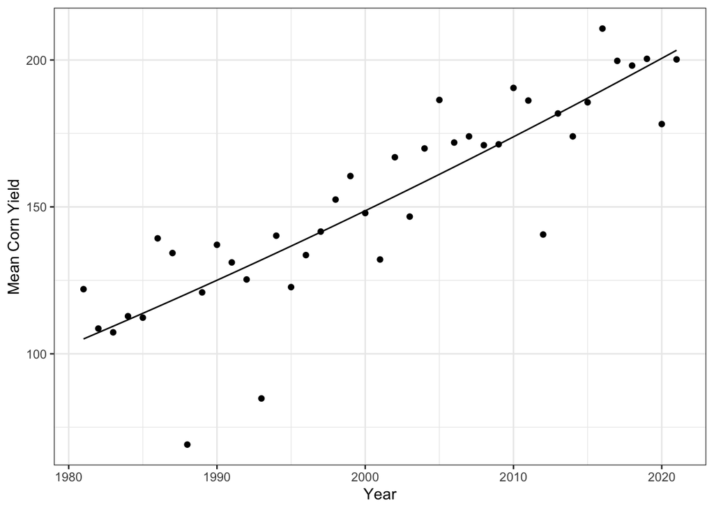

```r
winneyields$fitted <- lm_yieldsquad$fitted.values

ggplot(winneyields) +
  geom_point(mapping = aes(x = year, y = meanyield)) +
  geom_line(mapping = aes(x = year, y = fitted)) +
  theme_bw() +
  labs(x = "Year", y = "Mean Corn Yield")
```

### Question 2 – Time Series: Let’s analyze the relationship between temperature and yields for the Winneshiek County time series. Use data on yield and summer avg Tmax. Is adding year or Tmax^2 to your model helpful? Make a plot and interpret the results.

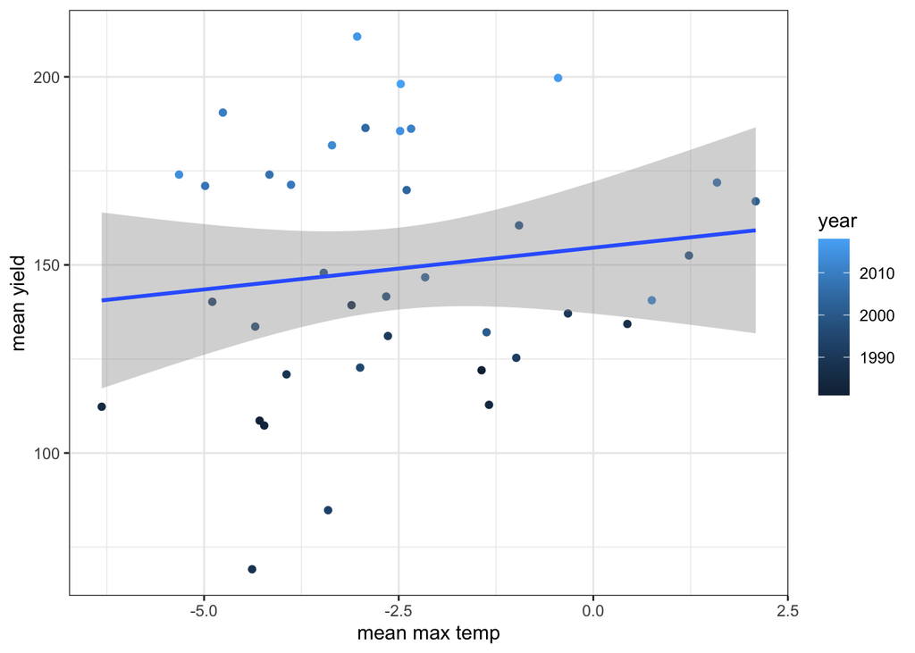

```r
#join the data together by year
tmaxyields<- winneyields %>%
  inner_join(winnewinter, by = "year")

#plot the data with a regression line
ggplot(data = tmaxyields)+
  geom_point(aes(x= meantmax, y = meanyield, color = year))+
  geom_smooth(aes(x= meantmax, y = meanyield),method = lm)+
  theme_bw()+
  labs(x = "mean max temp", y = "mean yield")
```

```r
#create the linear model
lm_tmaxyields <- lm(meanyield ~ meantmax , tmaxyields)

summary(lm_tmaxyields)
```

```
##
## Call:
## lm(formula = meanyield ~ meantmax, data = tmaxyields)
##
## Residuals:
##     Min      1Q  Median      3Q     Max
## -75.746 -24.005  -4.153  28.368  62.860
##
## Coefficients:
##             Estimate Std. Error t value Pr(>|t|)
## (Intercept)  154.570      8.645  17.879   <2e-16 ***
## meantmax       2.218      2.690   0.825    0.415
## ---
## Signif. codes:  0 '***' 0.001 '**' 0.01 '*' 0.05 '.' 0.1 ' ' 1
##
## Residual standard error: 33.1 on 36 degrees of freedom
## Multiple R-squared:  0.01854,    Adjusted R-squared:  -0.008724
## F-statistic:  0.68 on 1 and 36 DF,  p-value: 0.415
```

```r
#create a model with year as an additional explanatory variable
lm_tmaxyields_yr <- lm(meanyield ~ meantmax + year, tmaxyields)

summary(lm_tmaxyields_yr)
```

```
##
## Call:
## lm(formula = meanyield ~ meantmax + year, data = tmaxyields)
##
## Residuals:
##     Min      1Q  Median      3Q     Max
## -48.691  -2.189   2.655   8.033  25.049
##
## Coefficients:
##               Estimate Std. Error t value Pr(>|t|)
## (Intercept) -4889.6972   515.1416  -9.492 3.26e-11 ***
## meantmax        1.1767     1.4148   0.832    0.411
## year            2.5215     0.2575   9.792 1.46e-11 ***
## ---
## Signif. codes:  0 '***' 0.001 '**' 0.01 '*' 0.05 '.' 0.1 ' ' 1
##
## Residual standard error: 17.36 on 35 degrees of freedom
## Multiple R-squared:  0.7376, Adjusted R-squared:  0.7226
## F-statistic: 49.18 on 2 and 35 DF,  p-value: 6.809e-11
```

```r
tmaxyields$fitted <- lm_tmaxyields_yr$fitted.values

#create a model with meantmax squared values
tmaxyields$meantmaxsq <- tmaxyields$meantmax^2
lm_tmaxyields_sq <- lm(meanyield ~ meantmax + meantmaxsq, tmaxyields)
summary(lm_tmaxyields_sq)
```

```
##
## Call:
## lm(formula = meanyield ~ meantmax + meantmaxsq, data = tmaxyields)
##
## Residuals:
##     Min      1Q  Median      3Q     Max
## -75.207 -22.419  -3.591  29.128  61.689
##
## Coefficients:
##             Estimate Std. Error t value Pr(>|t|)
## (Intercept) 154.6790     8.7623  17.653   <2e-16 ***
## meantmax      0.7503     5.3725   0.140    0.890
## meantmaxsq   -0.3686     1.1627  -0.317    0.753
## ---
## Signif. codes:  0 '***' 0.001 '**' 0.01 '*' 0.05 '.' 0.1 ' ' 1
##
## Residual standard error: 33.52 on 35 degrees of freedom
## Multiple R-squared:  0.02135,    Adjusted R-squared:  -0.03457
## F-statistic: 0.3818 on 2 and 35 DF,  p-value: 0.6855
```

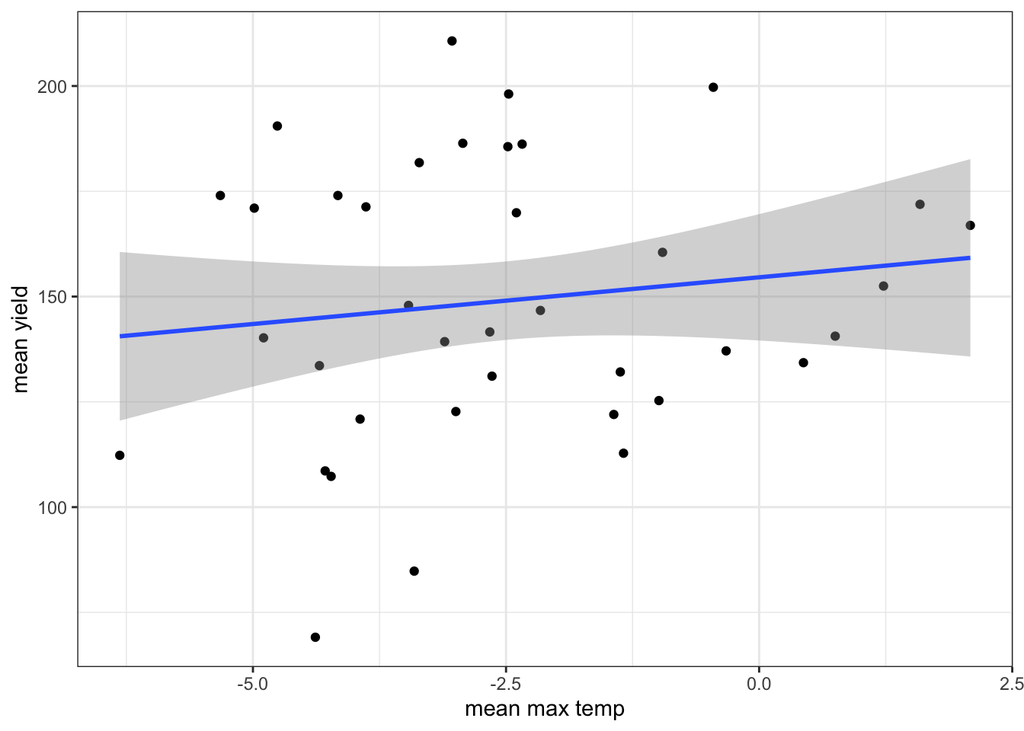

```r
ggplot(data = tmaxyields)+
  geom_point(aes(x= meantmax, y = meanyield))+
  geom_smooth(aes(x= meantmax, y = fitted), method = lm)+
  theme_bw()+
  labs(x = "mean max temp", y = "mean yield")
```

### Question 3 – Cross-Section: Analyze the relationship between temperature and yield across all counties in 2018. Is there a relationship? Interpret the results.

There is a significant quadratic relationship between temperature and yield across all counties, so yield was highest when temperatures were in the middle, and lowest when temperatures were either on the low end or the high end.

```r
#filter the corn yeild data to 2018 and convert county_ansi to factor
cornyields2018<-cornyields %>%
  filter(year == 2018) %>%
  mutate(across(county_ansi, factor))

#find the meantmax for summer of 2018
all_summer2018 <- tmaxdf %>%
  filter(year==2018 & doy >= 152 & doy <= 243) %>%
  group_by(countyfp) %>%
  summarize(meantmax = mean(tmax))

#join the yields with the temp data
all_cornyields2018<-cornyields2018 %>%
  inner_join(all_summer2018, by = c("county_ansi" = "countyfp"))

#create a linear model with yield and mean tmax
lm_yields2018 <- lm(yield ~ meantmax , all_cornyields2018)
summary(lm_yields2018)
```

```
##
## Call:
## lm(formula = yield ~ meantmax, data = all_cornyields2018)
##
## Residuals:
##     Min      1Q  Median      3Q     Max
## -42.983 -15.041   0.955  16.795  31.999
##
## Coefficients:
##             Estimate Std. Error t value Pr(>|t|)
## (Intercept)  312.466     63.387   4.929 3.69e-06 ***
## meantmax      -4.216      2.241  -1.882   0.0631 .
## ---
## Signif. codes:  0 '***' 0.001 '**' 0.01 '*' 0.05 '.' 0.1 ' ' 1
##
## Residual standard error: 19.64 on 91 degrees of freedom
## Multiple R-squared:  0.03745,    Adjusted R-squared:  0.02687
## F-statistic: 3.541 on 1 and 91 DF,  p-value: 0.06308
```

```r
#create a model with yeild, tmax, and tmax squared values
all_cornyields2018$meantmax_sq<-all_cornyields2018$meantmax^2

lm_yields2018_sq <- lm(yield ~ meantmax + meantmax_sq, all_cornyields2018)
summary(lm_yields2018_sq)
```

```
##
## Call:
## lm(formula = yield ~ meantmax + meantmax_sq, data = all_cornyields2018)
##
## Residuals:
##     Min      1Q  Median      3Q     Max
## -44.221 -15.399   5.007  14.541  30.879
##
## Coefficients:
##              Estimate Std. Error t value Pr(>|t|)
## (Intercept) -5501.602   1860.830  -2.957  0.00397 **
## meantmax      406.789    131.493   3.094  0.00263 **
## meantmax_sq    -7.256      2.321  -3.126  0.00239 **
## ---
## Signif. codes:  0 '***' 0.001 '**' 0.01 '*' 0.05 '.' 0.1 ' ' 1
##
## Residual standard error: 18.75 on 90 degrees of freedom
## Multiple R-squared:  0.1317, Adjusted R-squared:  0.1124
## F-statistic: 6.827 on 2 and 90 DF,  p-value: 0.001736
```

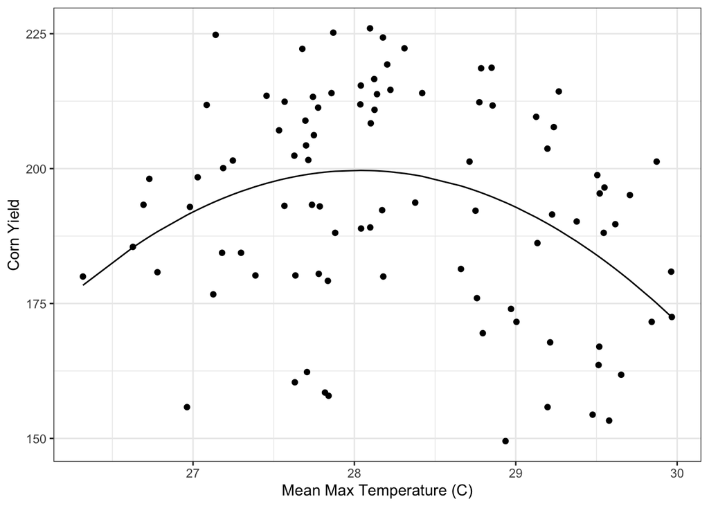

```r
all_cornyields2018$fitted <- lm_yields2018_sq$fitted.values

#plot the data
ggplot(data = all_cornyields2018, aes(x = meantmax, y = yield))+
  geom_point()+
  geom_line(aes(x = meantmax, y = fitted))+
  theme_bw()+
  labs(x = "Mean Max Temperature (C)", y = "Corn Yield")
```

### Question 4 – Panel: One way to leverage multiple time series is to group all data into what is called a “panel” regression. Convert the county ID code (“countyfp” or “county_ansi”) into factor using as.factor, then include this variable in a regression using all counties’ yield and summer temperature data. How does the significance of your temperature coefficients (Tmax, Tmax^2) change? Make a plot comparing actual and fitted yields and interpret the results of your model.

Including county in the regression reduces the significance of the temperature coefficients, but increases the significance for the relationship as a whole.

```r
#convert county_ansi to factor
cornyields<-cornyields %>%
  mutate(across(county_ansi, factor))

#find the meantmax for all counties, all years
all_summer <- tmaxdf %>%
  filter(doy >= 152 & doy <= 243) %>%
  group_by(countyfp) %>%
  summarize(meantmax = mean(tmax))

#join the yields with the temp data
all_cornyields<-cornyields %>%
  inner_join(all_summer, by = c("county_ansi" = "countyfp"))

#create a tmax squared column
all_cornyields$meantmax_sq<-all_cornyields$meantmax^2

#create a panel regression
lm_all_cornyields_panel<-lm(yield ~ meantmax + meantmax_sq + county_ansi + year, all_cornyields)

summary(lm_all_cornyields_panel)
```

```
##
## Call:
## lm(formula = yield ~ meantmax + meantmax_sq + county_ansi + year,
##     data = all_cornyields)
##
## Residuals:
##      Min       1Q   Median       3Q      Max
## -101.016   -9.576    3.141   14.498   52.720
##
## Coefficients: (2 not defined because of singularities)
##                  Estimate Std. Error t value Pr(>|t|)
## (Intercept)    -1.231e+04  3.338e+03  -3.687 0.000230 ***
## meantmax        5.806e+02  2.427e+02   2.392 0.016804 *
## meantmax_sq    -1.070e+01  4.410e+00  -2.425 0.015342 *
## county_ansi3   -4.686e+00  4.746e+00  -0.987 0.323535
## county_ansi5   -6.692e+00  4.232e+00  -1.582 0.113843
## county_ansi7   -1.653e+01  5.103e+00  -3.240 0.001205 **
## county_ansi9   -1.335e+00  4.442e+00  -0.300 0.763859
## county_ansi11  -3.608e+00  4.706e+00  -0.767 0.443313
## county_ansi13  -4.201e+00  4.729e+00  -0.888 0.374423
## county_ansi15   6.970e+00  4.426e+00   1.575 0.115335
## county_ansi17   1.865e-01  4.610e+00   0.040 0.967729
## county_ansi19  -2.828e+00  4.528e+00  -0.625 0.532285
## county_ansi21  -2.473e+00  4.750e+00  -0.521 0.602733
## county_ansi23  -1.219e+00  4.755e+00  -0.256 0.797709
## county_ansi25  -1.576e-01  4.730e+00  -0.033 0.973427
## county_ansi27   1.731e+00  4.524e+00   0.383 0.702095
## county_ansi29   6.294e+00  4.627e+00   1.360 0.173834
## county_ansi31   5.032e+00  4.634e+00   1.086 0.277570
## county_ansi33  -6.213e+00  4.334e+00  -1.434 0.151773
## county_ansi35   4.203e+00  4.719e+00   0.891 0.373133
## county_ansi37  -7.031e+00  4.253e+00  -1.653 0.098351 .
## county_ansi39  -2.288e+01  4.987e+00  -4.589 4.59e-06 ***
## county_ansi41  -5.112e+00  4.728e+00  -1.081 0.279650
## county_ansi43  -2.250e+00  4.386e+00  -0.513 0.608055
## county_ansi45   2.360e-01  4.689e+00   0.050 0.959860
## county_ansi47  -7.674e-01  4.595e+00  -0.167 0.867394
## county_ansi49   7.567e+00  4.413e+00   1.715 0.086456 .
## county_ansi51  -4.647e+00  7.628e+00  -0.609 0.542424
## county_ansi53  -1.291e+01  5.462e+00  -2.365 0.018095 *
```

[output cut: 64 more lines]

```
## county_ansi183  1.426e+01  5.724e+00   2.491 0.012775 *
## county_ansi185 -2.234e+01  4.622e+00  -4.833 1.39e-06 ***
## county_ansi187  3.745e+00  4.738e+00   0.790 0.429372
## county_ansi189 -9.692e-01  4.230e+00  -0.229 0.818787
## county_ansi191 -3.172e+00  4.420e+00  -0.718 0.473024
## county_ansi193  6.811e-01  4.333e+00   0.157 0.875108
## county_ansi195         NA         NA      NA       NA
## county_ansi197         NA         NA      NA       NA
## year            2.292e+00  2.881e-02  79.557  < 2e-16 ***
## ---
## Signif. codes:  0 '***' 0.001 '**' 0.01 '*' 0.05 '.' 0.1 ' ' 1
##
## Residual standard error: 21.43 on 3915 degrees of freedom
## Multiple R-squared:  0.6579, Adjusted R-squared:  0.6493
## F-statistic: 76.05 on 99 and 3915 DF,  p-value: < 2.2e-16
```

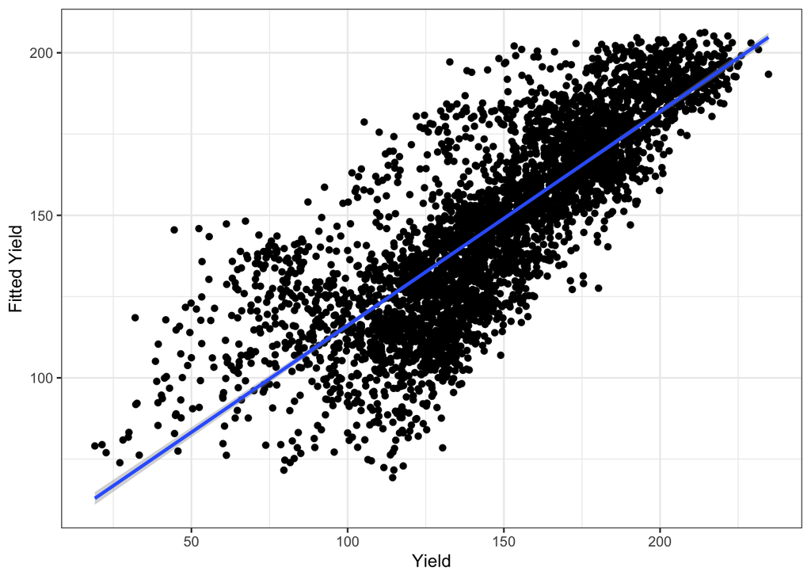

```r
all_cornyields$fitted<-lm_all_cornyields_panel$fitted.values

ggplot(data = all_cornyields)+
  geom_point(aes(x = yield, y = fitted))+
  geom_smooth(aes(x = yield, y = fitted), method = lm)+
  theme_bw()+
  labs(x = "Yield", y = "Fitted Yield")
```

### Question 5 – Soybeans: Download NASS data on soybean yields and explore either a time series relationship for a given county, the cross-sectional relationship for a given year, or a panel across all counties and years.

```r
#set parameters for downloading the soy data
params_soy <- list(commodity_desc = "SOYBEANS", util_practice_desc = "GRAIN", prodn_practice_desc = "ALL PRODUCTION PRACTICES", year__GE = 1981, state_alpha = "IA")

# download the data
soyyieldsall <- nassqs_yields(params)
```

[figure not shown]

```r
#convert variables to numeric
soyyieldsall$county_ansi <- as.numeric(soyyieldsall$county_ansi)
soyyieldsall$yield <- as.numeric(soyyieldsall$Value)

# clean and filter the data
soyyields <- select(soyyieldsall, county_ansi, county_name, yield, year) %>%
  filter(!is.na(county_ansi) & !is.na(yield))
soyyields <- tibble(soyyields)

#filter to Winneshiek County yields and calculate mean
winneyields_soy <- soyyields %>%
  filter(county_ansi==191)

ggplot(data = winneyields_soy, aes(x = year, y = yield))+
  geom_point()+
  theme_bw()+
  labs(title="Winneshiek County", x = "Year", y = "Mean Soy Yield")+
  geom_smooth(method = lm)
```

[output not shown]